# Week 03: Ensemble Learning & Random Forests

## 3.2.1 Decision Boundary Evolution: 1 → 500 Trees

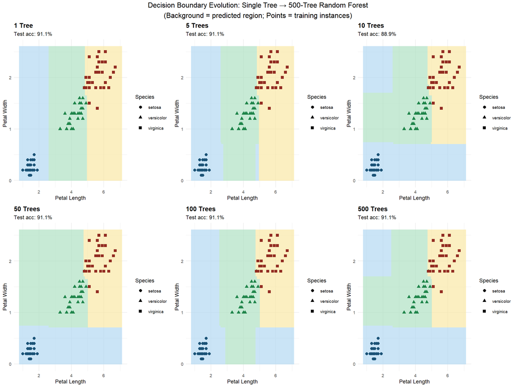

```r
set.seed(MASTER_SEED)

# Use 2-feature iris for a clean 2D boundary plot
iris_2d_full <- iris[, c("Petal.Length", "Petal.Width", "Species")]
train_2d <- iris_2d_full[train_idx, ]
test_2d  <- iris_2d_full[-train_idx, ]

# Create a fine prediction grid
pl_rng <- range(iris$Petal.Length)
pw_rng <- range(iris$Petal.Width)
grid_2d <- expand.grid(
  Petal.Length = seq(pl_rng[1] - 0.2, pl_rng[2] + 0.2, length.out = 150),
  Petal.Width  = seq(pw_rng[1] - 0.1, pw_rng[2] + 0.1, length.out = 150)
)

# Build a large RF; we'll use predictions from the first k trees
rf_big <- randomForest(
  Species ~ .,
  data    = train_2d,
  ntree   = 500,
  mtry    = 1,
  importance = FALSE
)

# Boundary for a single decision tree
single_dt <- rpart(Species ~ ., data = train_2d, control = rpart.control(maxdepth = 5))
grid_2d$single_tree <- predict(single_dt, grid_2d, type = "class")

# RF predictions on grid for boundary regions
all_preds_grid <- predict(rf_big, grid_2d, predict.all = TRUE)$individual
# Separately predict on the actual test set (must NOT slice grid rows)
all_preds_test <- predict(rf_big, test_2d, predict.all = TRUE)$individual
# all_preds_grid: nrow(grid_2d) x 500; all_preds_test: nrow(test_2d) x 500

ntree_snapshots <- c(1, 5, 10, 50, 100, 500)
species_levels  <- levels(iris$Species)

snap_list <- lapply(ntree_snapshots, function(nt) {
  subset_preds <- all_preds_grid[, 1:nt, drop = FALSE]
  # $individual is a character matrix (class names), not 1/2/3 codes
  maj_class <- apply(subset_preds, 1, function(row) {
    tbl <- table(row)
    match(names(tbl)[which.max(tbl)], species_levels)
  })
  data.frame(
    Petal.Length = grid_2d$Petal.Length,
    Petal.Width  = grid_2d$Petal.Width,
    pred_class   = factor(species_levels[maj_class], levels = species_levels),
    ntree        = nt
  )
})
boundary_df <- do.call(rbind, snap_list)

palette_rf <- c(setosa = "#AED6F1", versicolor = "#A9DFBF", virginica = "#F9E79F")

plots_bd <- lapply(ntree_snapshots, function(nt) {
  bd_sub <- filter(boundary_df, ntree == nt)
  # Use test set predictions from rf_big (not the grid rows)
  maj_test <- apply(all_preds_test[, 1:nt, drop = FALSE], 1, function(row) {
    tbl <- table(row)
    names(tbl)[which.max(tbl)]
  })
  acc_nt <- mean(maj_test == as.character(test_2d$Species))

  ggplot() +
    geom_tile(data = bd_sub, aes(x = Petal.Length, y = Petal.Width, fill = pred_class),
              alpha = 0.65) +
    geom_point(data = train_2d,
               aes(x = Petal.Length, y = Petal.Width, color = Species, shape = Species),
               size = 2) +
    scale_fill_manual(values = palette_rf, guide = "none") +
    scale_color_manual(values = c(setosa = "#1A5276", versicolor = "#1E8449",
                                   virginica = "#922B21"), guide = "none") +
    labs(
      title    = sprintf("%d %s", nt, if (nt == 1) "Tree" else "Trees"),
      subtitle = sprintf("Test acc: %.1f%%", acc_nt * 100),
      x = "Petal Length", y = "Petal Width"
    ) +
    theme_minimal(base_size = 9) +
    theme(plot.title = element_text(face = "bold"))
})

do.call(grid.arrange, c(plots_bd, ncol = 3,
  top = "Decision Boundary Evolution: Single Tree → 500-Tree Random Forest\n(Background = predicted region; Points = training instances)"))
```

## 3.3 Prediction and Evaluation

```r
rf_pred <- predict(rf_iris, iris_test)
rf_acc  <- mean(rf_pred == iris_test$Species)

cat(sprintf("Random Forest Test Accuracy: %.1f%%\n", rf_acc * 100))
```

```
## Random Forest Test Accuracy: 91.1%
```

```r
# Confusion matrix
table(Predicted = rf_pred, Actual = iris_test$Species)
```

```
##             Actual
## Predicted    setosa versicolor virginica
##   setosa         13          0         0
##   versicolor      0         13         2
##   virginica       0          2        15
```

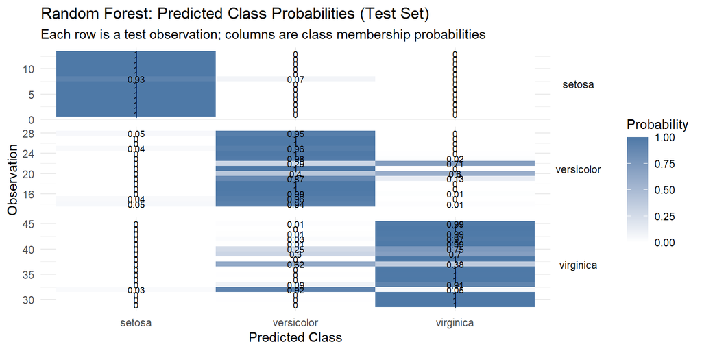

```r
# Class probability heatmap
prob_mat <- predict(rf_iris, iris_test, type = "prob")
prob_df <- as.data.frame(prob_mat) %>%
  mutate(obs = 1:n(), actual = iris_test$Species) %>%
  pivot_longer(cols = c(setosa, versicolor, virginica),
               names_to = "class", values_to = "prob")

ggplot(prob_df, aes(x = class, y = obs, fill = prob)) +
  geom_tile() +
  geom_text(aes(label = round(prob, 2)), size = 2.5) +
  facet_grid(actual ~ ., scales = "free_y", space = "free") +
  scale_fill_gradient(low = "white", high = "#4E79A7") +
  labs(
    title = "Random Forest: Predicted Class Probabilities (Test Set)",
    subtitle = "Each row is a test observation; columns are class membership probabilities",
    x = "Predicted Class", y = "Observation", fill = "Probability"
  ) +
  theme_minimal() +
  theme(strip.text.y = element_text(angle = 0))
```

## 3.4 How Individual Trees Vote: A Closer Look

For any given test observation, the RF prediction is simply the **majority vote** across all trees. But votes are rarely unanimous — some observations are confidently predicted while others are borderline. Let’s visualize the vote distribution for several test points.

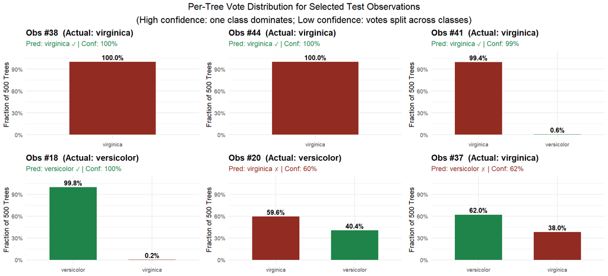

```r
set.seed(MASTER_SEED)

# Use the 500-tree full iris RF
all_test_votes <- predict(rf_iris, iris_test, predict.all = TRUE)$individual
# randomForest returns class NAMES (character matrix), not numeric 1/2/3

# Select 6 representative observations: 2 easy (pure), 2 moderate, 2 borderline
vote_summaries <- lapply(1:nrow(iris_test), function(i) {
  votes <- all_test_votes[i, ]
  tbl   <- table(votes)
  max_frac <- max(tbl) / ncol(all_test_votes)
  data.frame(obs = i, max_frac = max_frac,
             actual = as.character(iris_test$Species[i]))
}) %>% do.call(rbind, .) %>%
  arrange(max_frac)

# Pick 2 from each confidence tier
chosen_obs <- c(
  tail(vote_summaries$obs, 2),         # most confident (near 100%)
  vote_summaries$obs[c(                 # moderate
    floor(nrow(vote_summaries) * 0.4),
    floor(nrow(vote_summaries) * 0.6))],
  head(vote_summaries$obs, 2)           # least confident (borderline)
)

vote_plots <- lapply(seq_along(chosen_obs), function(idx) {
  i <- chosen_obs[idx]
  votes     <- all_test_votes[i, ]
  vote_df   <- as.data.frame(table(votes)) %>%
    mutate(Species = as.character(votes),
           Fraction = Freq / ncol(all_test_votes))
  true_sp   <- as.character(iris_test$Species[i])
  predicted <- names(which.max(table(votes)))
  correct   <- (predicted == true_sp)
  conf      <- max(table(votes)) / ncol(all_test_votes)

  ggplot(vote_df, aes(x = reorder(Species, -Fraction), y = Fraction, fill = Species)) +
    geom_col(width = 0.6) +
    geom_text(aes(label = scales::percent(Fraction, accuracy = 0.1)),
              vjust = -0.4, fontface = "bold", size = 3) +
    scale_fill_manual(values = c(setosa = "#1A5276", versicolor = "#1E8449",
                                  virginica = "#922B21"), guide = "none") +
    scale_y_continuous(labels = scales::percent, limits = c(0, 1.1)) +
    labs(
      title    = sprintf("Obs #%d  (Actual: %s)", i, true_sp),
      subtitle = sprintf("Pred: %s %s | Conf: %.0f%%",
                         predicted, ifelse(correct, "✓", "✗"), conf * 100),
      x = NULL, y = "Fraction of 500 Trees"
    ) +
    theme_minimal(base_size = 9) +
    theme(
      plot.title    = element_text(face = "bold"),
      plot.subtitle = element_text(color = ifelse(correct, "#1E8449", "#922B21"))
    )
})

do.call(grid.arrange, c(vote_plots, ncol = 3,
  top = "Per-Tree Vote Distribution for Selected Test Observations\n(High confidence: one class dominates; Low confidence: votes split across classes)"))
```

# Part 4: Feature Importance

One of Random Forests’ most useful properties is **automatic feature ranking**. Scikit-Learn measures importance by how much each feature **reduces node impurity** (Gini or MSE), weighted by the proportion of training samples passing through that node, averaged across all trees **[1]**.

$$\text{Importance}(X_j) = \frac{1}{B}
\sum_{b=1}^{B} \sum_{t \in \mathcal{T}_b} \frac{n_t}{N} \cdot \Delta
\text{impurity}(t, X_j)$$

where $B$ = number of trees, $\mathcal{T}_b$ = set of nodes in tree $b$ that split on $X_j$, $n_t$ = samples at node $t$, $N$ = total training samples.

In R’s `randomForest`, importance is available in two flavors: - **MeanDecreaseAccuracy**: how much accuracy drops when the feature is randomly permuted (OOB-based) - **MeanDecreaseGini**: total decrease in node impurity summed across trees

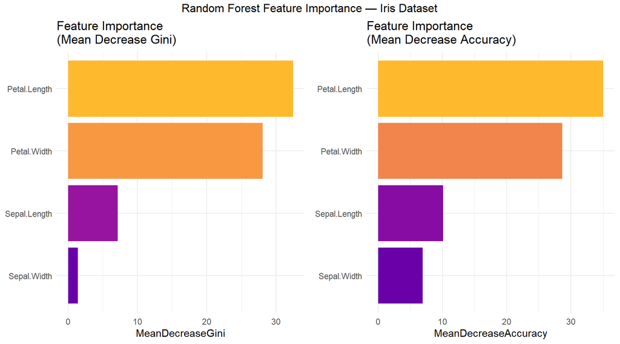

```r
imp <- importance(rf_iris)
imp_df <- as.data.frame(imp) %>%
  rownames_to_column("Feature") %>%
  arrange(desc(MeanDecreaseGini))

p1 <- ggplot(imp_df, aes(x = reorder(Feature, MeanDecreaseGini),
                          y = MeanDecreaseGini, fill = MeanDecreaseGini)) +
  geom_col() +
  coord_flip() +
  scale_fill_viridis_c(option = "plasma", begin = 0.2, end = 0.85) +
  labs(title = "Feature Importance\n(Mean Decrease Gini)", x = NULL) +
  theme_minimal() +
  theme(legend.position = "none")

p2 <- ggplot(imp_df, aes(x = reorder(Feature, MeanDecreaseAccuracy),
                          y = MeanDecreaseAccuracy, fill = MeanDecreaseAccuracy)) +
  geom_col() +
  coord_flip() +
  scale_fill_viridis_c(option = "plasma", begin = 0.2, end = 0.85) +
  labs(title = "Feature Importance\n(Mean Decrease Accuracy)", x = NULL) +
  theme_minimal() +
  theme(legend.position = "none")

grid.arrange(p1, p2, ncol = 2,
  top = "Random Forest Feature Importance — Iris Dataset")
```

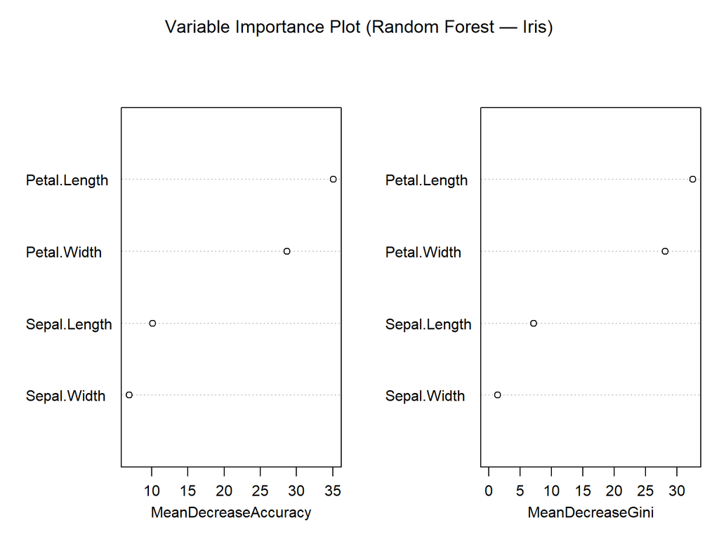

```r
varImpPlot(rf_iris,
  main = "Variable Importance Plot (Random Forest — Iris)")
```

> **Interpretation:** Petal features dominate. This matches the Decision Tree results from Week 02 — `Petal.Length` and `Petal.Width` are the most discriminative features for classifying Iris species.

> **Caution:** Gini importance can be biased toward features with many unique values (high cardinality). Permutation importance (MeanDecreaseAccuracy) is more reliable but slower to compute.

## 4.1 Feature Usage Heatmap: Which Features Split Which Trees?

Beyond *how important* features are, we can ask: *in which trees is each feature actually used for splitting?* This heatmap shows **how many times each feature is used across all splits** in each tree — revealing how the random subset mechanism distributes feature usage across the forest.

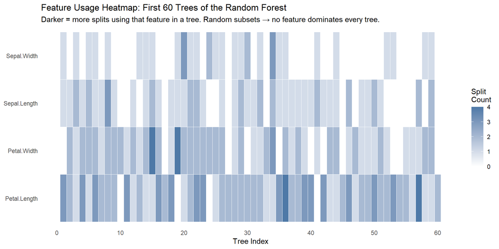

```r
set.seed(MASTER_SEED)
n_show_trees <- 60

# Feature usage per tree: count how many splits use each feature
feature_usage <- lapply(1:n_show_trees, function(k) {
  tree_k  <- getTree(rf_iris, k = k, labelVar = TRUE)
  splits  <- tree_k[tree_k$status == 1, "split var"]
  feats   <- names(iris)[-5]
  counts  <- sapply(feats, function(f) sum(splits == f))
  data.frame(Tree = k, Feature = feats, Count = counts)
}) %>% do.call(rbind, .)

ggplot(feature_usage, aes(x = Tree, y = Feature, fill = Count)) +
  geom_tile(color = "white", linewidth = 0.3) +
  scale_fill_gradient(low = "white", high = "#4E79A7",
                      name = "Split\nCount") +
  scale_x_continuous(breaks = seq(0, n_show_trees, 10)) +
  labs(
    title    = sprintf("Feature Usage Heatmap: First %d Trees of the Random Forest", n_show_trees),
    subtitle = "Darker = more splits using that feature in a tree. Random subsets → no feature dominates every tree.",
    x = "Tree Index", y = NULL
  ) +
  theme_minimal() +
  theme(panel.grid = element_blank())
```

> **Reading the heatmap:** Each cell shows how many splits in tree $j$ used feature $i$. Dark columns mean that tree relied heavily on a particular feature. The variation across columns shows that random feature subsetting achieves its goal — different trees learn from different aspects of the data.

# Part 4b: Bias-Variance Tradeoff — RF vs. Single Tree

One of the most fundamental results in statistical learning theory is the **Bias-Variance tradeoff**:

$$\text{Expected Error} = \text{Bias}^2 +
\text{Variance} + \text{Irreducible Noise}$$

A single deep Decision Tree has **low bias** (it fits training data well) but **high variance** (it changes wildly with different training sets). Random Forests dramatically **reduce variance** while keeping bias roughly constant. We can demonstrate this empirically:

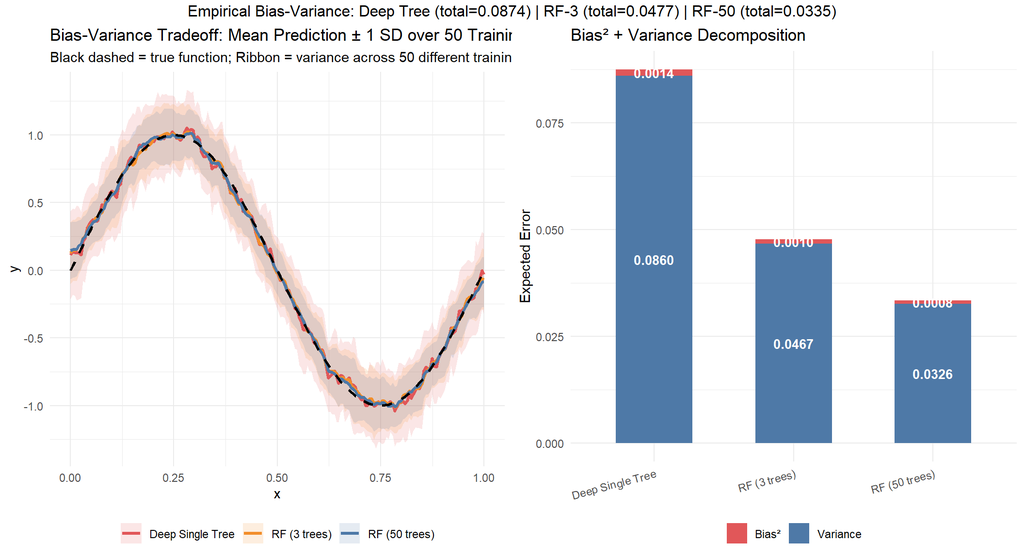

```r
set.seed(MASTER_SEED)

# Simulate a regression task: y = sin(2*pi*x) + noise
n_train   <- 80
n_test    <- 200
n_repeats <- 50  # number of different training sets

x_test  <- seq(0, 1, length.out = n_test)
y_true  <- sin(2 * pi * x_test)

# Storage for predictions from each model across repetitions
preds_tree <- matrix(NA, nrow = n_test, ncol = n_repeats)
preds_rf3  <- matrix(NA, nrow = n_test, ncol = n_repeats)
preds_rf50 <- matrix(NA, nrow = n_test, ncol = n_repeats)

for (r in 1:n_repeats) {
  x_tr <- runif(n_train)
  y_tr <- sin(2 * pi * x_tr) + rnorm(n_train, sd = 0.3)
  df_tr <- data.frame(x = x_tr, y = y_tr)
  df_te <- data.frame(x = x_test)

  # Deep single tree
  t_m <- rpart(y ~ x, data = df_tr,
               control = rpart.control(maxdepth = 8, cp = 0, minsplit = 2))
  preds_tree[, r] <- predict(t_m, df_te)

  # RF with 3 trees (small — still high variance)
  rf3 <- randomForest(y ~ x, data = df_tr, ntree = 3)
  preds_rf3[, r] <- predict(rf3, df_te)

  # RF with 50 trees (converged)
  rf50 <- randomForest(y ~ x, data = df_tr, ntree = 50)
  preds_rf50[, r] <- predict(rf50, df_te)
}

# Compute bias^2 and variance for each model
bv_stats <- function(pred_mat, y_true) {
  mean_pred <- rowMeans(pred_mat)
  bias2     <- mean((mean_pred - y_true)^2)
  variance  <- mean(apply(pred_mat, 1, var))
  list(bias2 = bias2, variance = variance, total = bias2 + variance)
}

st_tree <- bv_stats(preds_tree, y_true)
st_rf3  <- bv_stats(preds_rf3,  y_true)
st_rf50 <- bv_stats(preds_rf50, y_true)

# Plot: mean prediction ± 1 SD ribbon for each model
make_ribbon_df <- function(pred_mat, label) {
  data.frame(
    x    = x_test,
    mean = rowMeans(pred_mat),
    sd   = apply(pred_mat, 1, sd),
    model = label
  )
}

ribbon_df <- bind_rows(
  make_ribbon_df(preds_tree, "Deep Single Tree"),
  make_ribbon_df(preds_rf3,  "RF (3 trees)"),
  make_ribbon_df(preds_rf50, "RF (50 trees)")
) %>%
  mutate(model = factor(model, levels = c("Deep Single Tree", "RF (3 trees)", "RF (50 trees)")))

cols_bv <- c("Deep Single Tree" = "#E15759", "RF (3 trees)" = "#F28E2B", "RF (50 trees)" = "#4E79A7")

p_ribbon <- ggplot(ribbon_df, aes(x = x, color = model, fill = model)) +
  geom_ribbon(aes(ymin = mean - sd, ymax = mean + sd), alpha = 0.15, color = NA) +
  geom_line(aes(y = mean), linewidth = 1.1) +
  geom_line(data = data.frame(x = x_test, y = y_true),
            aes(x = x, y = y), color = "black", linetype = "dashed",
            linewidth = 1, inherit.aes = FALSE) +
  scale_color_manual(values = cols_bv) +
  scale_fill_manual(values  = cols_bv) +
  labs(
    title    = "Bias-Variance Tradeoff: Mean Prediction ± 1 SD over 50 Training Sets",
    subtitle = "Black dashed = true function; Ribbon = variance across 50 different training datasets",
    x = "x", y = "y", color = NULL, fill = NULL
  ) +
  theme_minimal() +
  theme(legend.position = "bottom")

# Bar chart of bias^2 vs variance
bv_df <- data.frame(
  Model    = rep(c("Deep Single Tree", "RF (3 trees)", "RF (50 trees)"), each = 2),
  Component = rep(c("Bias²", "Variance"), 3),
  Value    = c(st_tree$bias2, st_tree$variance,
               st_rf3$bias2,  st_rf3$variance,
               st_rf50$bias2, st_rf50$variance)
) %>%
  mutate(Model = factor(Model, levels = c("Deep Single Tree", "RF (3 trees)", "RF (50 trees)")))

p_bar <- ggplot(bv_df, aes(x = Model, y = Value, fill = Component)) +
  geom_col(position = "stack", width = 0.55) +
  geom_text(aes(label = sprintf("%.4f", Value)),
            position = position_stack(vjust = 0.5),
            color = "white", fontface = "bold", size = 3.5) +
  scale_fill_manual(values = c("Bias²" = "#E15759", "Variance" = "#4E79A7")) +
  labs(
    title = "Bias² + Variance Decomposition",
    x = NULL, y = "Expected Error", fill = NULL
  ) +
  theme_minimal() +
  theme(legend.position = "bottom", axis.text.x = element_text(angle = 15, hjust = 1))

grid.arrange(p_ribbon, p_bar, ncol = 2,
  top = sprintf(
    "Empirical Bias-Variance: Deep Tree (total=%.4f) | RF-3 (total=%.4f) | RF-50 (total=%.4f)",
    st_tree$total, st_rf3$total, st_rf50$total))
```

# Part 5: Hyperparameter Tuning

## 5.1 Key Hyperparameters

Random Forest Hyperparameters in R’s `randomForest` Package

| Parameter | Controls | Default | Tuning Tip |
| --- | --- | --- | --- |
| ntree | Number of trees in the forest | 500 | Plot OOB curve; stop when it flattens |
| mtry | Number of features sampled at each split | √p (classif.) / p/3 (regr.) | Try √p, √p/2, 2√p; tune via OOB |
| nodesize | Minimum size of terminal (leaf) nodes | 1 (classif.) / 5 (regr.) | Larger → smaller trees (regularization) |
| maxnodes | Maximum number of leaf nodes per tree | Unlimited | Equivalent to max_depth control |
| sampsize | Size of bootstrap sample | N (with replacement) | Smaller → more variance reduction (more diversity) |

## 5.2 Tuning `mtry`

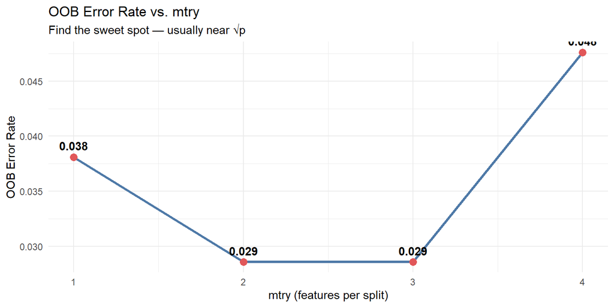

```r
set.seed(MASTER_SEED)
mtry_vals <- 1:4
oob_by_mtry <- sapply(mtry_vals, function(m) {
  rf_m <- randomForest(Species ~ ., data = iris_train, ntree = 300, mtry = m)
  rf_m$err.rate[300, "OOB"]
})

ggplot(data.frame(mtry = mtry_vals, oob = oob_by_mtry), aes(x = mtry, y = oob)) +
  geom_line(color = "#4E79A7", linewidth = 1.2) +
  geom_point(size = 3, color = "#E15759") +
  geom_text(aes(label = sprintf("%.3f", oob)), vjust = -0.8, fontface = "bold") +
  labs(
    title = "OOB Error Rate vs. mtry",
    subtitle = "Find the sweet spot — usually near √p",
    x = "mtry (features per split)", y = "OOB Error Rate"
  ) +
  scale_x_continuous(breaks = mtry_vals) +
  theme_minimal()
```

```r
best_mtry <- mtry_vals[which.min(oob_by_mtry)]
cat("Best mtry:", best_mtry, "| OOB error:", round(min(oob_by_mtry), 4))
```

```
## Best mtry: 2 | OOB error: 0.0286
```

## 5.3 Effect of Tree Depth (nodesize)

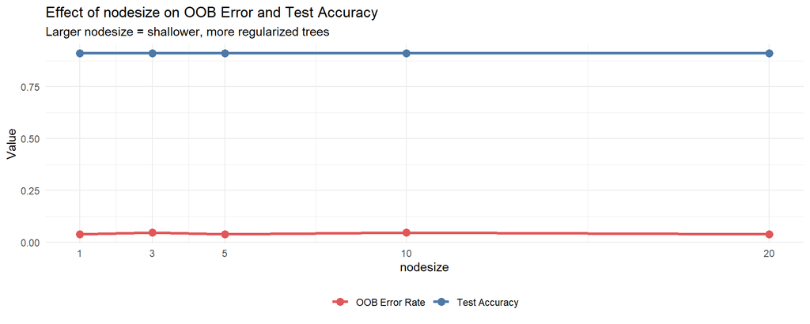

```r
set.seed(MASTER_SEED)
nodesizes <- c(1, 3, 5, 10, 20)
results_ns <- lapply(nodesizes, function(ns) {
  rf_ns <- randomForest(Species ~ ., data = iris_train,
                         ntree = 300, nodesize = ns, importance = FALSE)
  data.frame(
    nodesize = ns,
    oob_err  = rf_ns$err.rate[300, "OOB"],
    test_acc = mean(predict(rf_ns, iris_test) == iris_test$Species)
  )
})
results_ns <- do.call(rbind, results_ns)

ggplot(results_ns %>%
         pivot_longer(c(oob_err, test_acc), names_to = "metric", values_to = "value") %>%
         mutate(metric = recode(metric, oob_err = "OOB Error Rate",
                                        test_acc = "Test Accuracy")),
       aes(x = nodesize, y = value, color = metric)) +
  geom_line(linewidth = 1.2) +
  geom_point(size = 3) +
  scale_color_manual(values = c("OOB Error Rate" = "#E15759", "Test Accuracy" = "#4E79A7")) +
  labs(
    title = "Effect of nodesize on OOB Error and Test Accuracy",
    subtitle = "Larger nodesize = shallower, more regularized trees",
    x = "nodesize", y = "Value", color = NULL
  ) +
  scale_x_continuous(breaks = nodesizes) +
  theme_minimal() +
  theme(legend.position = "bottom")
```